# Guía 1

```r
library(janitor)
```

## Ejercicio 1

Supongamos que queremos averiguar cuál es la superficie de la Tierra cubierta por agua, $\theta$. Para eso, lanzamos al aire un globo terráqueo y al atraparlo, registramos si nuestro dedo índice de la mano derecha quedó marcando agua o tierra. De esta manera obtenemos una secuencia de muestras aleatorias de una variable Bernouilli($\theta$) independientes.

1. –
2. Usando la distribución posterior calculada, obtener la distribución “posterior predictive” para las siguiente 5 muestras aleatorias

```r
set.seed(42)
simulation <-data.frame(theta = rbeta(10000, 5, 12)) %>%
  mutate(y = rbinom(10000, size = 5, prob = theta))
prop.table(table(simulation$y))
```

```
     0      1      2      3      4      5
0.2134 0.3398 0.2642 0.1336 0.0430 0.0060
```

## Ejercicio 2

Siguiente el procedimiento del ejercicio anterior y partiendo de una distribución uniforme, graficar la distribución posterior luego de observar A. Luego, usando esa distribución posterior como prior, calcular y graficar la distribición posterior luego de observar T. Continuar este proceso para ver cómo se actualiza secuencialmente la distribución posterior cuando sucesivamente obtenemos (después de las dos primeras muestras aleatorias) {A, A, A, T, A, T, A}.

**Asumo que observe solo un exito: A**

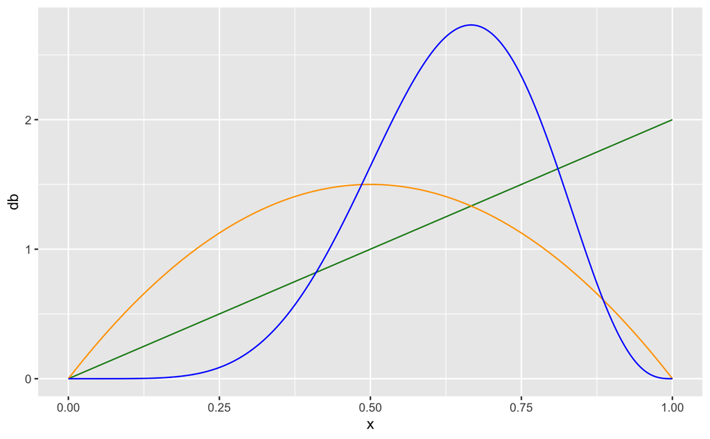

```r
x <- seq(0,1,length=1000)
db <- dbeta(x, 2, 1)
db2 <- dbeta(x, 2, 2)
db3 <- dbeta(x, 7, 4)
ggplot() +
  geom_line(aes(x,db), color='forestgreen') +
  geom_line(aes(x,db2), color='orange') +
  geom_line(aes(x,db3), color='blue')
```

## Ejercicio 3

Repetir el ejercicio 2 pero partir de un prior triangular, con máximo en $\theta=0.5$. Para hacerlo, hacer una aproximación de grilla para calcular la posterior. Esto es:

1. Definir un vector de valores de $\theta$ en los cuales se quiere estimar la posterior.
2. Calcular el prior para cada valor $\theta$ en esa grilla.
3. Calcular la función de likelihood para valor del parámetro.
4. Calcular la posterior no normalizada multiplicando el prior por el likelihood.
5. Normalizar la posterior dividiendo por la suma de todos sus valores.

```r
# a. valores de theta en los cuales se quiere estimar la posterior
grid_data <- data.frame(theta_grid = seq(from = 0, to = 1, length = 1000))

# b. Calcular el prior para cada valor \theta en esa grilla.
grid_data <- grid_data %>%
  mutate(prior = dtri(theta_grid, min=0, max=1, mode=1/2))

# c. calular la función de likelihood para valor del parámetro.

grid_data <- grid_data %>%
  # observé solo A
  mutate(likelihood_1 = dbinom(1, 1,theta_grid),
  # observé A, T
          likelihood_2 = dbinom(1, 2, theta_grid),
  # observé {A, T} U {A, A, A, T, A, T, A}; #A = 6, #T = 3
        likelihood_3 = dbinom(6, 9, theta_grid))

# d. calcular la posterior no normalizada multiplicando prior por likelihood

grid_data <- grid_data %>%
 mutate(unnormalized_1 = likelihood_1 * prior,
        unnormalized_2 = likelihood_2 * prior,
        unnormalized_3 = likelihood_3 * prior)

# e. calcular la posterior dividiendo por la suma de todos sus valores

grid_data <- grid_data %>%
 mutate(posterior_1 = prop.table(unnormalized_1),
        posterior_2 = prop.table(unnormalized_2),
        posterior_3 = prop.table(unnormalized_3))

# verifico que sumen 1
grid_data %>%
  summarize(sum(posterior_1))
```

| sum(posterior_1) |
| --- |
| 1 |

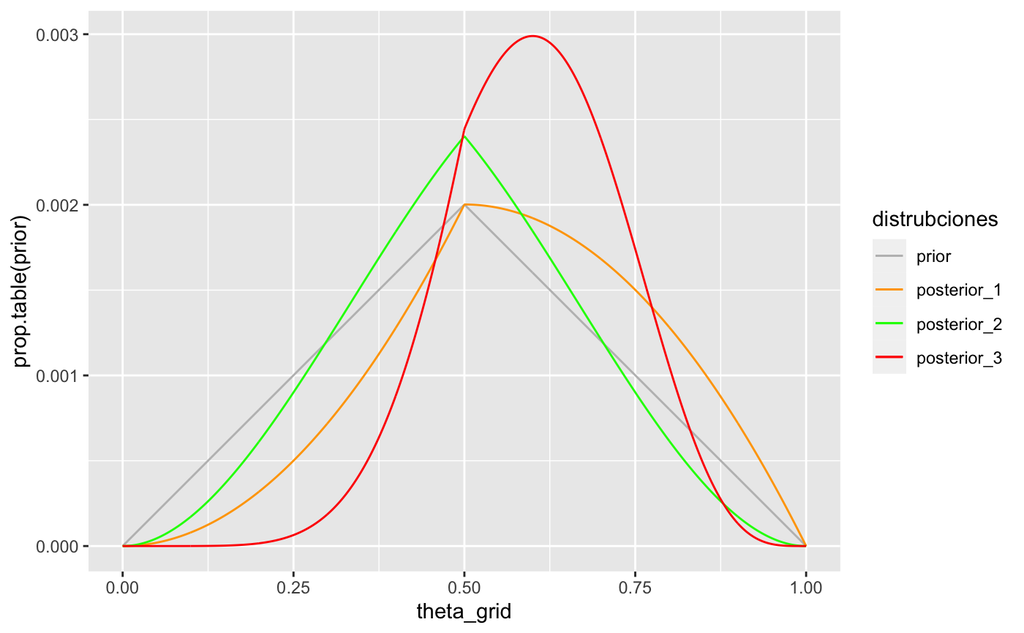

```r
grid_data %>%
  ggplot() +
  geom_line(aes(x=theta_grid, y=prop.table(prior), color='prior')) +
  geom_line(aes(x=theta_grid, y=posterior_1, color='posterior_1'))+
  geom_line(aes(x=theta_grid, y=posterior_2, color='posterior_2'))+
  geom_line(aes(x=theta_grid, y=posterior_3, color='posterior_3'))+
  scale_color_manual(values=c(
    'prior'='grey',
    'posterior_1'='orange',
    'posterior_2'='green',
    'posterior_3'='red')) +
  labs(color = 'distrubciones')
```

```r
NA
```

```r
x <- seq(0,1,length=1000)
prior <- dtri(x, min = 0, max = 1, mode = 1/2)
#
likelihood_1 <- dbeta(x,2,1)
posterior_1 <- prop.table(prior * likelihood_1)
likelihood_2 <- dbeta(x,2,2)
posterior_2 <- prop.table(prior * likelihood_2)
l <- dbinom(1, 2, x)
p <- prop.table(prior * l)
likelihood_3 <- dbeta(x,7,4)
posterior_3 <- prop.table(prior * likelihood_3)
ggplot() +
  #geom_line(aes(x,prior), color='darkgreen') +
  geom_line(aes(x,posterior_1), color= 'orange') +
  geom_line(aes(x,posterior_2), color= 'green') +
  geom_line(aes(x,p), color= 'red')
```

[output not shown]

## Ejercicio 4

Crear una función que genere $N$ datos del proceso aleatorio descripto en el ejercicio 1 tomando como parámetros $N$ y $\theta$. Crear otra función que calcule la distribución posterior partiendo de un prior uniforme, genere muestras de esta distribución y con esas muestras devuelva un intervalo de credibilidad del $50%$ de $\theta$. Con esta función, estimar el número mínimo de muestras aleatorias que se necesitan para estimar con un intervalo de credibilidad de ancho menor a $0.1$.

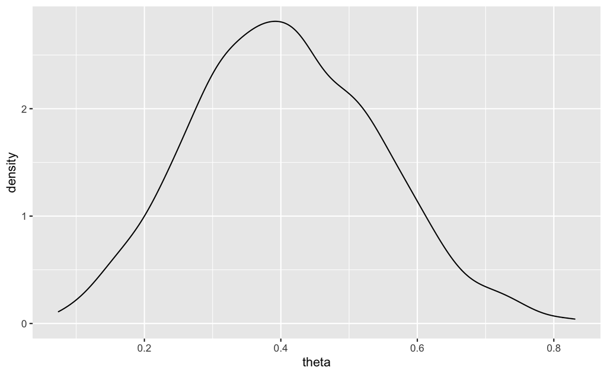

```r
simular <- function(N, theta){
  rbinom(N, 1, theta)
}

posterior_dist <- function(datos, N=1000){
  num_experimentos <- length(datos)
  num_exitos <- sum(datos)
  grid_data <- data.frame(theta_grid = seq(from=0,to=1,length=N)) %>%
  mutate(prior = dbeta(theta_grid, 1,1)) %>%
  mutate(likelihood = dbinom(num_exitos, size=num_experimentos, prob=theta_grid),
         posterior = prop.table(likelihood * prior))
  posterior_dist <- data.frame(theta = grid_data$theta_grid, posterior_proba = grid_data$posterior)
}


# aproximación de la posterior por grillas
datos <- simular(10, 0.3) # Theta verdadero es 0.3
posterior <- posterior_dist(datos)

# sampleo de la distribución posterior
posterior_samples <- sample_n(posterior, size=1000,
                              weight = posterior$posterior_proba, replace = T)

posterior_samples %>%
  ggplot(aes(x=theta)) +
  geom_density()
```

```r
intervalo_credibilidad <- quantile(posterior_samples$theta, c(0.25, 0.75))
intervalo_credibilidad <- unname(intervalo_credibilidad)
c(intervalo_credibilidad[1], intervalo_credibilidad[2])
```

```
[1] 0.3123123 0.5025025
```

```r
longitud <- intervalo_credibilidad[2]-intervalo_credibilidad[1]
longitud
```

```
[1] 0.1901902
```

## Ejercicio 5

Supongamos que estamos de espaldas a una mesa de pool separada en dos por una línea vertical. Juan y Alicia participan del siguiente juego. Tiran una pelota a la mesa que cae en un punto cualquiera, al azar. Si cae a la izquierda de la línea, Alicia gana 1 punto. Si cae a la derecha, Juan gana 1 punto. Gana el primero que llega a 6 puntos. Después de tirar 8 bolas, Alicia suma 5 puntos y Juan 3.

1. Calcular la distribución posterior para la probabilidad $\theta$ de que Juan gane el juego.

La distribución posterior es una $\beta (4,6)$

2. Tomar muestras de la posterior y con ellas obtener la esperanza de $\theta$. Comparar con el resultado visto en clase.

```r
# Tomo N muestras de una distribución Beta(4,6) y caluclo el promedio para estimar la esperanza
mean(rbeta(10000,4, 6))
```

[output not shown]

3. Simular este juego para obtener la probabilidad esperada de que gana Juan el juego, entendida como la cantidad de veces que gana Juan el juego condicional a que va perdiendo 5 a 3.

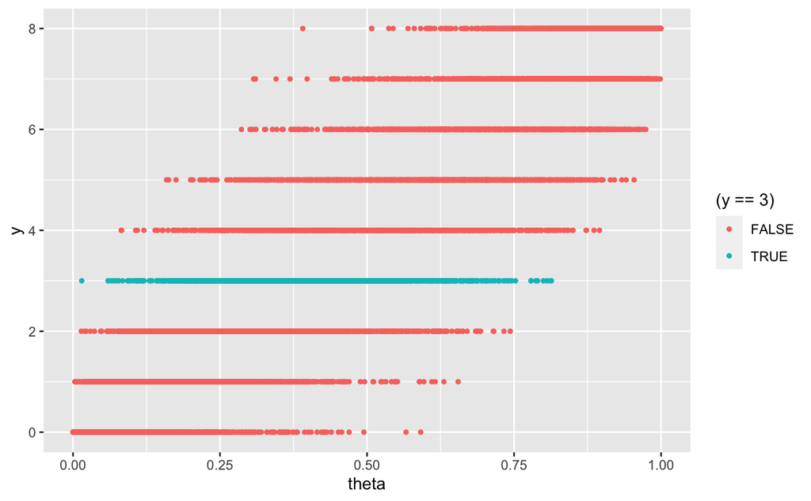

```r
# generamos la simulacion
set.seed(42)
simulacion_pool <- data.frame(theta = rbeta(10000, 1, 1)) %>%  # parto del prior uniforme
  mutate(y = rbinom(10000, size = 8, prob = theta)) # para cada theta, se juega 8 veces luego y es el número

simulacion_pool %>%
  ggplot(aes(x=theta, y=y)) +
  geom_point(aes(color = (y == 3)), size = 1)
```

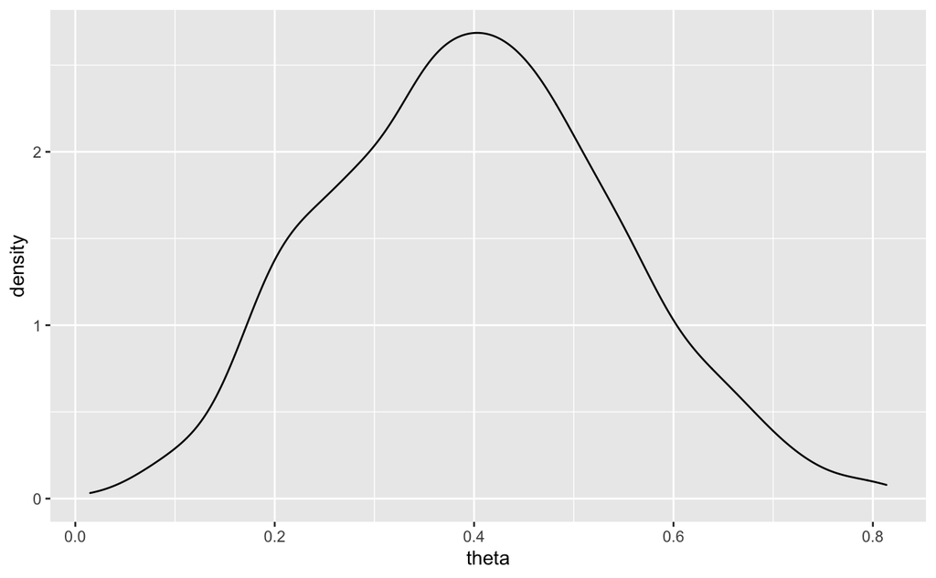

```r
simulacion_pool_posterior <- simulacion_pool %>%
  filter(y==3)

simulacion_pool_posterior %>%
  ggplot(aes(x=theta)) +
  geom_density()
```

```r
simulacion_pool_posterior %>%
  summarise(mean(theta))
```

| mean(theta) |
| --- |
| 0.4005645 |